# Asymmetric alignment paper, Experiment 1 analysis and graphs

Kenny Smith

8th May 2019

# Read in data and report Ns

```r
exp1.data <- read.csv("ProcessedData/Experiment1Data.csv")

#put Block in desired order
exp1.data$Block <- factor(exp1.data$Block,
                               levels=c("Training",
                                        "Recall 1",
                                        "Interaction Block 1",
                                        "Interaction Block 2",
                                        "Recall 2"))

#Required to avoid overlapping text in some plots
exp1.data$BlockNewlines <- plyr::revalue(exp1.data$Block,
                                   c("Interaction Block 1"="Interaction\nBlock 1",
                                      "Interaction Block 2"="Interaction\nBlock 2"))


#I want Pair as a factor
#Note: pairs 60-102 collected at Edinburgh, 151-190 collected at Warwick
exp1.data$Pair <- as.factor(exp1.data$Pair)

plyr::ddply(exp1.data,~Condition,plyr::summarise,Current_N=length(unique(Pair)))
```

```
##   Condition Current_N
## 1     66-33        20
## 2     83-17        20
```

# Brief report of communicative success

This is very high throughout.

```r
exp1.by.pair.scores <- aggregate(Score~Condition+Block+Pair,data=subset(exp1.data,Block %in% c("Interaction Block 1", "Interaction Block 2")),FUN=sum)

aggregate(Score~Condition,data=exp1.by.pair.scores,FUN=mean)
```

```
##   Condition  Score
## 1     66-33 46.625
## 2     83-17 46.900
```

```r
aggregate(Score~Block+Condition,data=exp1.by.pair.scores,FUN=mean)
```

```
##                 Block Condition Score
## 1 Interaction Block 1     66-33 46.65
## 2 Interaction Block 2     66-33 46.60
## 3 Interaction Block 1     83-17 46.55
## 4 Interaction Block 2     83-17 47.25
```

# Calculate and plot proportion of marked singulars by block

## Calculate proportions

```r
#We only want to analyse singulars
exp1.data.singulars <- subset(exp1.data,Number==1)
exp1.data.by.block <- aggregate(data=exp1.data.singulars,
                                       Marked~Condition + Pair + Block + BlockNewlines + Participant + ParticipantID,
                                       FUN=mean)

exp1.data.by.block <- plyr::rename(exp1.data.by.block,c("Marked"="ProportionMarkedSingulars"))

exp1.data.by.block$Condition <- plyr::revalue(exp1.data.by.block$Condition,
                                                 c("66-33"="Condition: 66-33",
                                                   "83-17"="Condition: 83-17"))
```

## Proportion plots

One graph for all raw data, another with one facet per pair, one with mean and 95% CIs.

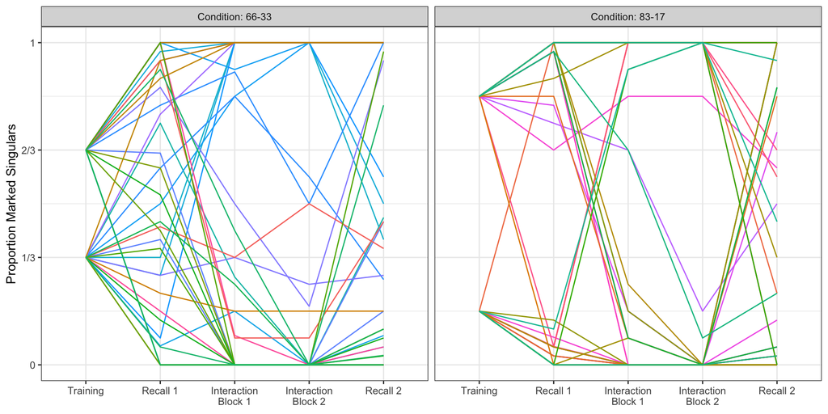

```r
#All data
ggplot(data=exp1.data.by.block, aes(x=BlockNewlines, y=ProportionMarkedSingulars, group=ParticipantID, colour=Pair,ymin=0,ymax=1)) +
  theme_bw() +
  facet_wrap(~Condition, ncol=4) +
  geom_line() +
  ylab("Proportion Marked Singulars") +
  theme(axis.title.x = element_blank()) +
  theme(legend.position="none") +
  scale_y_continuous(breaks=seq(0,1,1/3),labels=c("0","1/3","2/3","1"))
```

```r
#For faccetted by-pair plot, need to add a DummyPair column so that the facets work out nicely - this is a little clumsy, but simplest way to do this seems to be to split by condition and convert Pair factor to integers
exp1.data.by.block.6633 <- subset(exp1.data.by.block,Condition=='Condition: 66-33')

exp1.data.by.block.6633$DummyPair <- droplevels(exp1.data.by.block.6633$Pair)

#change levels to integers
levels(exp1.data.by.block.6633$DummyPair) <- 1:length(levels(exp1.data.by.block.6633$DummyPair))

#ditto for other condition
exp1.data.by.block.8317 <- subset(exp1.data.by.block,Condition=='Condition: 83-17')

exp1.data.by.block.8317$DummyPair <- droplevels(exp1.data.by.block.8317$Pair)

#change levels to integers
levels(exp1.data.by.block.8317$DummyPair) <- 1:length(levels(exp1.data.by.block.8317$DummyPair))

#and recombine
exp1.data.by.block.dummyp <- rbind(exp1.data.by.block.6633,exp1.data.by.block.8317)
```

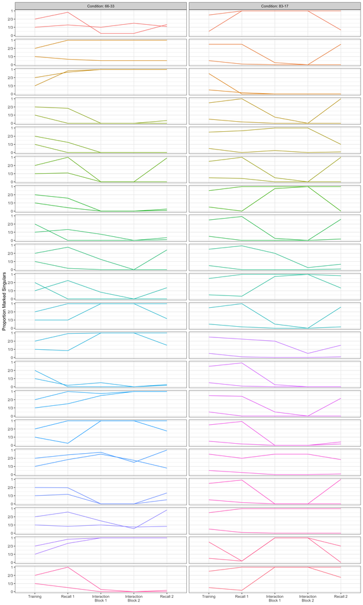

```r
#By-pair figure
ggplot(data=exp1.data.by.block.dummyp, aes(x=BlockNewlines, y=ProportionMarkedSingulars, group=ParticipantID, colour=Pair,ymin=0,ymax=1)) +
  theme_bw() +
  facet_grid(DummyPair ~ Condition) +
  geom_line() +
  ylab("Proportion Marked Singulars") +
  theme(legend.position="none") +
  scale_y_continuous(breaks=seq(0,1,1/3),labels=c("0","1/3","2/3","1")) +
  theme(strip.text.y = element_blank()) +
  theme(axis.title.x = element_blank())
```

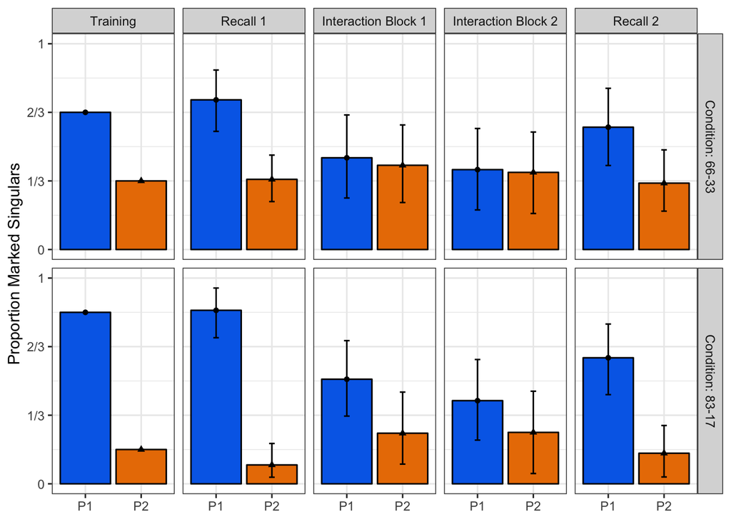

```r
#Means and CIs
ggplot(data=exp1.data.by.block, aes(x=Participant, y=ProportionMarkedSingulars, group=Participant, shape=Participant,fill=Participant)) +
  theme_bw() +
  facet_grid(Condition~Block) +
  stat_summary(geom='bar', fun.y='mean', position='dodge',colour='black') +
  stat_summary(geom='errorbar',fun.data='mean_cl_boot',fun.ymin="min", fun.ymax="max",colour="black",width=0.1) +
  #stat_summary(geom='errorbar',colour="black",width=0.1) +
  stat_summary(geom='point', fun.y='mean', position='dodge',colour='black') +
  scale_fill_manual(values=c(my.colours[2],my.colours[1],my.colours[3])) +
  coord_cartesian(ylim=c(0,1)) +
  scale_y_continuous(breaks=seq(0,1,1/3),labels=c("0","1/3","2/3","1")) +
  ylab("Proportion Marked Singulars") +
  theme(axis.title.x = element_blank()) +
  theme(legend.position="none")
```

## Count of systematic users / non-users at Recall 1

```r
systematic.users <- subset(exp1.data.by.block,Block=="Recall 1" & (ProportionMarkedSingulars==1 | ProportionMarkedSingulars==0))
plyr::ddply(systematic.users,~Condition,plyr::summarise,Current_N=length(unique(Pair)))
```

```
##          Condition Current_N
## 1 Condition: 66-33        11
## 2 Condition: 83-17        13
```

## Count of systematic users / non-users at end of interaction

```r
systematic.users <- subset(exp1.data.by.block,Block=="Interaction Block 2" & (ProportionMarkedSingulars==1 | ProportionMarkedSingulars==0))
plyr::ddply(systematic.users,~Condition,plyr::summarise,Current_N=length(unique(Pair)))
```

```
##          Condition Current_N
## 1 Condition: 66-33        17
## 2 Condition: 83-17        20
```

## Count of systematic users / non-user pairs at end of interaction

```r
#In order to count convergence on systematic use/non-use, aggregating over participants in each pair
exp1.data.by.block.agg <- aggregate(ProportionMarkedSingulars~Condition+Pair+Block,data=exp1.data.by.block,FUN=mean)
systematic.user.pairs <- subset(exp1.data.by.block.agg,Block=="Interaction Block 2" & ProportionMarkedSingulars==1)
plyr::ddply(subset(systematic.user.pairs),~Condition,plyr::summarise,Current_N=length(unique(Pair)))
```

```
##          Condition Current_N
## 1 Condition: 66-33         6
## 2 Condition: 83-17         5
```

```r
systematic.nonuser.pairs <- subset(exp1.data.by.block.agg,Block=="Interaction Block 2" & ProportionMarkedSingulars==0)
plyr::ddply(subset(systematic.nonuser.pairs),~Condition,plyr::summarise,Current_N=length(unique(Pair)))
```

```
##          Condition Current_N
## 1 Condition: 66-33        10
## 2 Condition: 83-17        10
```

# Plot change from block to block, run statistics on those changes

```r
#The most convenient way to calculate differences from block to block is to restructure the data to wide format.
#BlockNewlines causes irritation here, so selecting it out
exp1.change.data <- tidyr::spread(data=dplyr::select(exp1.data.by.block,-BlockNewlines),Block,ProportionMarkedSingulars)

exp1.change.data$ChangeTrainingRecall1 <- exp1.change.data$'Recall 1' - exp1.change.data$'Training'

exp1.change.data$ChangeRecall1Interaction2 <- exp1.change.data$'Interaction Block 2'-exp1.change.data$'Recall 1'

exp1.change.data$ChangeRecall1Recall2 <- exp1.change.data$'Recall 2'-exp1.change.data$'Recall 1'


#convert back to long format for plotting
exp1.change.data.for.plotting <- dplyr::select(exp1.change.data,-Training,-'Recall 1',-'Recall 2',-'Interaction Block 1',-'Interaction Block 2')

exp1.change.data.for.plotting <- tidyr::gather(exp1.change.data.for.plotting,
BlockToBlock,Change,ChangeTrainingRecall1,ChangeRecall1Interaction2,ChangeRecall1Recall2)

#Make column names more user-friendly
exp1.change.data.for.plotting$BlockToBlock <- plyr::revalue(exp1.change.data.for.plotting$BlockToBlock,
                                                   c("ChangeTrainingRecall1"="Training to Recall 1",
                                                     "ChangeRecall1Interaction2"="Recall 1 to Interaction Block 2",
                                                     "ChangeRecall1Recall2"="Recall 1 to Recall 2"))

#I often want to plot Both Ps as well as P1 and P2 - to do this, I am duplicating the data amnd labelling the duplicate as "Both Ps" in the Participant column
exp1.change.data.for.plotting.Pscombined <- exp1.change.data.for.plotting
exp1.change.data.for.plotting.Pscombined$Participant <- "Both Ps"
exp1.change.data.for.plotting.combined <- rbind(exp1.change.data.for.plotting,exp1.change.data.for.plotting.Pscombined)
#Reorder the levels so that the BothPs data is last
exp1.change.data.for.plotting.combined$Participant <- factor(exp1.change.data.for.plotting.combined$Participant,levels=c("P1","P2","Both Ps"))

#I also want to show the effect for the two conditions combined, since there is often no difference between conditions - again, I duplicate the dataframe and label the Condition column for the combined dataframe as "Both Conditions"
exp1.change.data.for.plotting.Cscombined <- exp1.change.data.for.plotting.combined
exp1.change.data.for.plotting.Cscombined$Condition <- "Both Conditions"
exp1.change.data.for.plotting.combined <- rbind(exp1.change.data.for.plotting.combined,exp1.change.data.for.plotting.Cscombined)
#Reorder the levels so that the Both Conditions data is first
exp1.change.data.for.plotting.combined$Condition <- relevel(exp1.change.data.for.plotting.combined$Condition,ref=c("Both Conditions"))

#Reorder the levels ot BlockToBlock so that they reflect experiment order
exp1.change.data.for.plotting.combined$BlockToBlock <- factor(exp1.change.data.for.plotting.combined$BlockToBlock,levels=c("Training to Recall 1","Recall 1 to Interaction Block 2","Recall 1 to Recall 2"))
```

## Plots and stats for probability matching (change from Training to Recall 1)

### Plot of change for Training to Recall 1.

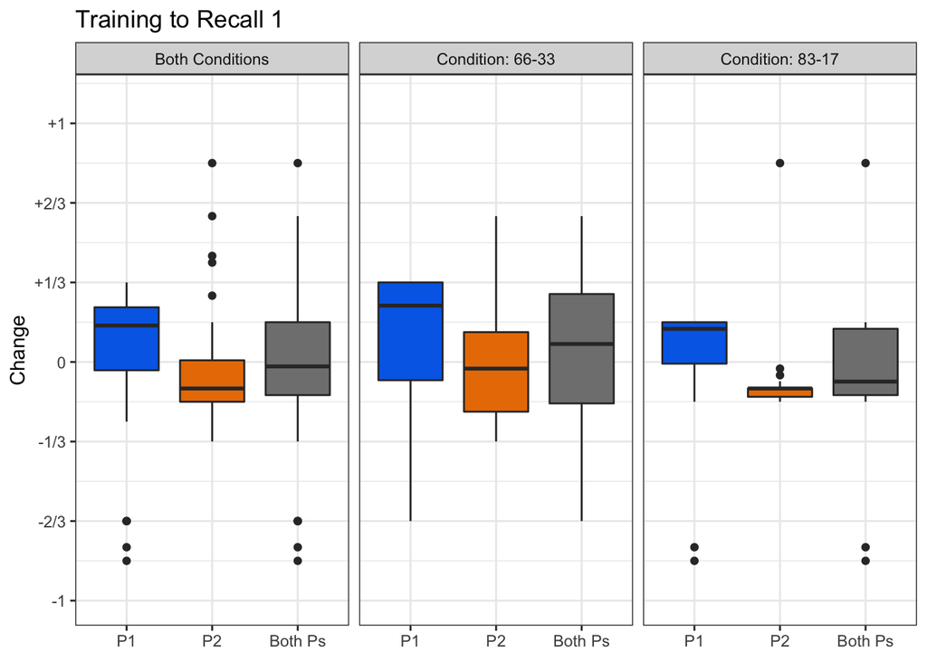

```r
ggplot(data=subset(exp1.change.data.for.plotting.combined,BlockToBlock=="Training to Recall 1"), aes(x=Participant, y=Change, fill=Participant)) +
  theme_bw() +
  facet_grid(. ~ Condition) +
  geom_boxplot() +
  scale_fill_manual(values=c(my.colours[2],my.colours[1],my.colours[3])) +
  scale_y_continuous(limits = c(-1,1.1),breaks=seq(-1,1,1/3),labels=c("-1","-2/3","-1/3","0","+1/3","+2/3","+1")) +
  ylab("Change") +
  theme(axis.title.x = element_blank()) +
  theme(legend.position="none") +
  ggtitle("Training to Recall 1")
```

### Stats for probability matching (change from Training to Recall 1)

Q1a: do the conditions differ in change from trainign to recall 1? **No significant difference**.

```r
wilcox.test(subset(exp1.change.data,Condition=="Condition: 66-33")$ChangeTrainingRecall1,
            subset(exp1.change.data,Condition=="Condition: 83-17")$ChangeTrainingRecall1)
```

```
##
##  Wilcoxon rank sum test with continuity correction
##
## data:  subset(exp1.change.data, Condition == "Condition: 66-33")$ChangeTrainingRecall1 and subset(exp1.change.data, Condition == "Condition: 83-17")$ChangeTrainingRecall1
## W = 964, p-value = 0.1151
## alternative hypothesis: true location shift is not equal to 0
```

Q1b: do the Ps differ in accuracy?. **Yes**.

```r
wilcox.test(subset(exp1.change.data,Participant=="P1")$ChangeTrainingRecall1,
            subset(exp1.change.data,Participant=="P2")$ChangeTrainingRecall1)
```

```
##
##  Wilcoxon rank sum test with continuity correction
##
## data:  subset(exp1.change.data, Participant == "P1")$ChangeTrainingRecall1 and subset(exp1.change.data, Participant == "P2")$ChangeTrainingRecall1
## W = 1099.5, p-value = 0.00396
## alternative hypothesis: true location shift is not equal to 0
```

Q2a: Does the change from training differ from 0? Doing this for all data, since the initial test suggests no difference between conditions. **No significant difference**.

```r
wilcox.test(exp1.change.data$ChangeTrainingRecall1)
```

```
##
##  Wilcoxon signed rank test with continuity correction
##
## data:  exp1.change.data$ChangeTrainingRecall1
## V = 1643, p-value = 0.6113
## alternative hypothesis: true location is not equal to 0
```

Q2b: since the effect of P was significant, testing P1 and P2 seperately

Some evidence for a significant shift in both (marginal for P1s, clearer in P2s).

```r
wilcox.test(subset(exp1.change.data,Participant=="P1")$ChangeTrainingRecall1)
```

```
##
##  Wilcoxon signed rank test with continuity correction
##
## data:  subset(exp1.change.data, Participant == "P1")$ChangeTrainingRecall1
## V = 530, p-value = 0.05111
## alternative hypothesis: true location is not equal to 0
```

```r
wilcox.test(subset(exp1.change.data,Participant=="P2")$ChangeTrainingRecall1)
```

```
##
##  Wilcoxon signed rank test with continuity correction
##
## data:  subset(exp1.change.data, Participant == "P2")$ChangeTrainingRecall1
## V = 240.5, p-value = 0.03729
## alternative hypothesis: true location is not equal to 0
```

A reviewer asked for all statistics to be run on each condition seperately, even in the absence of differences between condition.

```r
wilcox.test(subset(exp1.change.data,Condition=="Condition: 66-33" & Participant=="P1")$ChangeTrainingRecall1,
            subset(exp1.change.data,Condition=="Condition: 66-33" & Participant=="P2")$ChangeTrainingRecall1)
```

```
##
##  Wilcoxon rank sum test with continuity correction
##
## data:  subset(exp1.change.data, Condition == "Condition: 66-33" & Participant ==  and subset(exp1.change.data, Condition == "Condition: 66-33" & Participant ==     "P1")$ChangeTrainingRecall1 and     "P2")$ChangeTrainingRecall1
## W = 246, p-value = 0.2175
## alternative hypothesis: true location shift is not equal to 0
```

```r
wilcox.test(subset(exp1.change.data,Condition=="Condition: 83-17" & Participant=="P1")$ChangeTrainingRecall1,
            subset(exp1.change.data,Condition=="Condition: 83-17" & Participant=="P2")$ChangeTrainingRecall1)
```

```
##
##  Wilcoxon rank sum test with continuity correction
##
## data:  subset(exp1.change.data, Condition == "Condition: 83-17" & Participant ==  and subset(exp1.change.data, Condition == "Condition: 83-17" & Participant ==     "P1")$ChangeTrainingRecall1 and     "P2")$ChangeTrainingRecall1
## W = 319, p-value = 0.001233
## alternative hypothesis: true location shift is not equal to 0
```

Q3b: Does the change from training differ from 0? **n.s. for both conditions when considered independently**.

```r
wilcox.test(subset(exp1.change.data,Condition=="Condition: 66-33")$ChangeTrainingRecall1)
```

```
##
##  Wilcoxon signed rank test with continuity correction
##
## data:  subset(exp1.change.data, Condition == "Condition: 66-33")$ChangeTrainingRecall1
## V = 478, p-value = 0.2218
## alternative hypothesis: true location is not equal to 0
```

```r
wilcox.test(subset(exp1.change.data,Condition=="Condition: 83-17")$ChangeTrainingRecall1)
```

```
##
##  Wilcoxon signed rank test with continuity correction
##
## data:  subset(exp1.change.data, Condition == "Condition: 83-17")$ChangeTrainingRecall1
## V = 333.5, p-value = 0.4336
## alternative hypothesis: true location is not equal to 0
```

Q3c: Testing P1 and P2 seperately for each condition. **No significant effects for P1 and P2 in the 66-33 condition. For the 83-17 condition there is no significant difference for the P1s, but a significant difference for the P2s, i.e. they are pulled significantly downwards**.

```r
wilcox.test(subset(exp1.change.data,Condition=="Condition: 66-33" & Participant=="P1")$ChangeTrainingRecall1)
```

```
##
##  Wilcoxon signed rank test with continuity correction
##
## data:  subset(exp1.change.data, Condition == "Condition: 66-33" & Participant ==     "P1")$ChangeTrainingRecall1
## V = 140, p-value = 0.1962
## alternative hypothesis: true location is not equal to 0
```

```r
wilcox.test(subset(exp1.change.data,Condition=="Condition: 66-33" & Participant=="P2")$ChangeTrainingRecall1)
```

```
##
##  Wilcoxon signed rank test with continuity correction
##
## data:  subset(exp1.change.data, Condition == "Condition: 66-33" & Participant ==     "P2")$ChangeTrainingRecall1
## V = 93.5, p-value = 0.9679
## alternative hypothesis: true location is not equal to 0
```

```r
wilcox.test(subset(exp1.change.data,Condition=="Condition: 83-17" & Participant=="P1")$ChangeTrainingRecall1)
```

```
##
##  Wilcoxon signed rank test with continuity correction
##
## data:  subset(exp1.change.data, Condition == "Condition: 83-17" & Participant ==     "P1")$ChangeTrainingRecall1
## V = 132, p-value = 0.1377
## alternative hypothesis: true location is not equal to 0
```

```r
wilcox.test(subset(exp1.change.data,Condition=="Condition: 83-17" & Participant=="P2")$ChangeTrainingRecall1)
```

```
##
##  Wilcoxon signed rank test with continuity correction
##
## data:  subset(exp1.change.data, Condition == "Condition: 83-17" & Participant ==     "P2")$ChangeTrainingRecall1
## V = 20, p-value = 0.001511
## alternative hypothesis: true location is not equal to 0
```

## Plots and stats for change in use due to interaction (change from Recall 1 to Interaction 2)

### Plot of change from Recall 1 to Interaction Block 2.

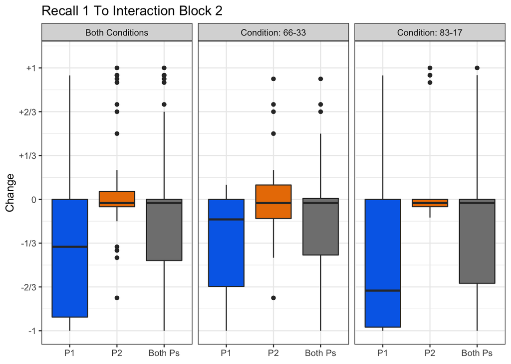

```r
ggplot(data=subset(exp1.change.data.for.plotting.combined,BlockToBlock=="Recall 1 to Interaction Block 2"), aes(x=Participant, y=Change, fill=Participant)) +
  theme_bw() +
  facet_grid(.~Condition) +
  geom_boxplot() +
  scale_fill_manual(values=c(my.colours[2],my.colours[1],my.colours[3])) +
  scale_y_continuous(limits = c(-1,1.1),breaks=seq(-1,1,1/3),labels=c("-1","-2/3","-1/3","0","+1/3","+2/3","+1")) +
  ylab("Change") +
  theme(axis.title.x = element_blank()) +
  theme(legend.position="none") +
  ggtitle("Recall 1 To Interaction Block 2")
```

### Stats for effect of interaction

Q1a: do the conditions differ in change from recall 1 to interaction 2? **No significant difference**.

```r
wilcox.test(subset(exp1.change.data,Condition=="Condition: 66-33")$ChangeRecall1Interaction2,
            subset(exp1.change.data,Condition=="Condition: 83-17")$ChangeRecall1Interaction2)
```

```
##
##  Wilcoxon rank sum test with continuity correction
##
## data:  subset(exp1.change.data, Condition == "Condition: 66-33")$ChangeRecall1Interaction2 and subset(exp1.change.data, Condition == "Condition: 83-17")$ChangeRecall1Interaction2
## W = 816.5, p-value = 0.8766
## alternative hypothesis: true location shift is not equal to 0
```

Q1b: do the Ps differ? **Yes**.

```r
wilcox.test(subset(exp1.change.data,Participant=="P1")$ChangeRecall1Interaction2,
            subset(exp1.change.data,Participant=="P2")$ChangeRecall1Interaction2)
```

```
##
##  Wilcoxon rank sum test with continuity correction
##
## data:  subset(exp1.change.data, Participant == "P1")$ChangeRecall1Interaction2 and subset(exp1.change.data, Participant == "P2")$ChangeRecall1Interaction2
## W = 531, p-value = 0.00918
## alternative hypothesis: true location shift is not equal to 0
```

Q2a: Does the change from Recall 1 to Interaction 2 differ from 0? **Yes**.

```r
wilcox.test(exp1.change.data$ChangeRecall1Interaction2)
```

```
##
##  Wilcoxon signed rank test with continuity correction
##
## data:  exp1.change.data$ChangeRecall1Interaction2
## V = 548.5, p-value = 0.007033
## alternative hypothesis: true location is not equal to 0
```

Q2b: Since the effect of Participant was significant, test this seperately for P1 and P2.

P1 show an effect.

P2 do not.

This suggests that participant with the higher frequency of marker use in their training (the P1s) change more, and downwards, during interaction.

```r
wilcox.test(subset(exp1.change.data,Participant=="P1")$ChangeRecall1Interaction2)
```

```
##
##  Wilcoxon signed rank test with continuity correction
##
## data:  subset(exp1.change.data, Participant == "P1")$ChangeRecall1Interaction2
## V = 33, p-value = 0.000184
## alternative hypothesis: true location is not equal to 0
```

```r
wilcox.test(subset(exp1.change.data,Participant=="P2")$ChangeRecall1Interaction2)
```

```
##
##  Wilcoxon signed rank test with continuity correction
##
## data:  subset(exp1.change.data, Participant == "P2")$ChangeRecall1Interaction2
## V = 283, p-value = 0.9715
## alternative hypothesis: true location is not equal to 0
```

As per the reviewer request, also analysing each condition separately.

Q3a: do the Ps differ? **Marginally so for both conditions**.

```r
wilcox.test(subset(exp1.change.data,Condition=="Condition: 66-33" & Participant=="P1")$ChangeRecall1Interaction2,
            subset(exp1.change.data,Condition=="Condition: 66-33" & Participant=="P2")$ChangeRecall1Interaction2)
```

```
##
##  Wilcoxon rank sum test with continuity correction
##
## data:  subset(exp1.change.data, Condition == "Condition: 66-33" & Participant ==  and subset(exp1.change.data, Condition == "Condition: 66-33" & Participant ==     "P1")$ChangeRecall1Interaction2 and     "P2")$ChangeRecall1Interaction2
## W = 135.5, p-value = 0.08162
## alternative hypothesis: true location shift is not equal to 0
```

```r
wilcox.test(subset(exp1.change.data,Condition=="Condition: 83-17" & Participant=="P1")$ChangeRecall1Interaction2,
            subset(exp1.change.data,Condition=="Condition: 83-17" & Participant=="P2")$ChangeRecall1Interaction2)
```

```
##
##  Wilcoxon rank sum test with continuity correction
##
## data:  subset(exp1.change.data, Condition == "Condition: 83-17" & Participant ==  and subset(exp1.change.data, Condition == "Condition: 83-17" & Participant ==     "P1")$ChangeRecall1Interaction2 and     "P2")$ChangeRecall1Interaction2
## W = 130, p-value = 0.05706
## alternative hypothesis: true location shift is not equal to 0
```

Q3b: does the overall change from Recall 1 to Interaction 2 differs from 0 in each condition seperately. **Change is significantly different from 0 in the 66-33 condition, and marginal in the 83-17 condition**.

```r
wilcox.test(subset(exp1.change.data,Condition=="Condition: 66-33")$ChangeRecall1Interaction2)
```

```
##
##  Wilcoxon signed rank test with continuity correction
##
## data:  subset(exp1.change.data, Condition == "Condition: 66-33")$ChangeRecall1Interaction2
## V = 142.5, p-value = 0.03959
## alternative hypothesis: true location is not equal to 0
```

```r
wilcox.test(subset(exp1.change.data,Condition=="Condition: 83-17")$ChangeRecall1Interaction2)
```

```
##
##  Wilcoxon signed rank test with continuity correction
##
## data:  subset(exp1.change.data, Condition == "Condition: 83-17")$ChangeRecall1Interaction2
## V = 129, p-value = 0.05676
## alternative hypothesis: true location is not equal to 0
```

Q3b: And testing this seperately for P1 and P2 in each condition. **In both conditions, P1s show an effect, P2s do not.**

```r
wilcox.test(subset(exp1.change.data,Condition=="Condition: 66-33" & Participant=="P1")$ChangeRecall1Interaction2)
```

```
##
##  Wilcoxon signed rank test with continuity correction
##
## data:  subset(exp1.change.data, Condition == "Condition: 66-33" & Participant ==     "P1")$ChangeRecall1Interaction2
## V = 6, p-value = 0.006403
## alternative hypothesis: true location is not equal to 0
```

```r
wilcox.test(subset(exp1.change.data,Condition=="Condition: 66-33" & Participant=="P2")$ChangeRecall1Interaction2)
```

```
##
##  Wilcoxon signed rank test with continuity correction
##
## data:  subset(exp1.change.data, Condition == "Condition: 66-33" & Participant ==     "P2")$ChangeRecall1Interaction2
## V = 85, p-value = 1
## alternative hypothesis: true location is not equal to 0
```

```r
wilcox.test(subset(exp1.change.data,Condition=="Condition: 83-17" & Participant=="P1")$ChangeRecall1Interaction2)
```

```
##
##  Wilcoxon signed rank test with continuity correction
##
## data:  subset(exp1.change.data, Condition == "Condition: 83-17" & Participant ==     "P1")$ChangeRecall1Interaction2
## V = 10, p-value = 0.008151
## alternative hypothesis: true location is not equal to 0
```

```r
wilcox.test(subset(exp1.change.data,Condition=="Condition: 83-17" & Participant=="P2")$ChangeRecall1Interaction2)
```

```
##
##  Wilcoxon signed rank test with continuity correction
##
## data:  subset(exp1.change.data, Condition == "Condition: 83-17" & Participant ==     "P2")$ChangeRecall1Interaction2
## V = 54, p-value = 0.7537
## alternative hypothesis: true location is not equal to 0
```

## Plots and stats for lasting effect of interaction (change from pre-interaction Recall 1 to post-interaction Recall 2)

### Plot for Recall 1 to Recall 2.

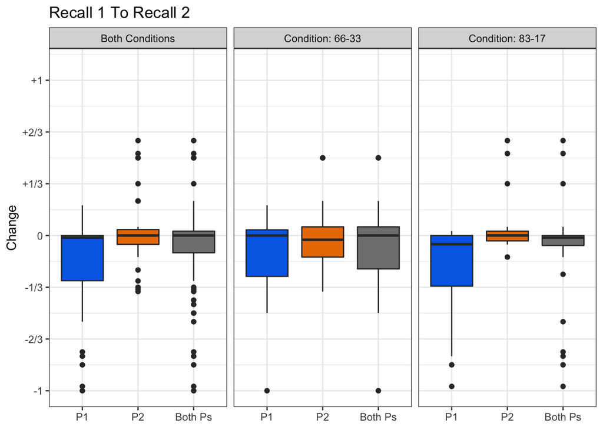

```r
ggplot(data=subset(exp1.change.data.for.plotting.combined,BlockToBlock=="Recall 1 to Recall 2"), aes(x=Participant, y=Change, fill=Participant)) +
  theme_bw() +
  facet_grid(.~Condition) +
  geom_boxplot() +
  scale_fill_manual(values=c(my.colours[2],my.colours[1],my.colours[3])) +
  scale_y_continuous(limits = c(-1,1.1),breaks=seq(-1,1,1/3),labels=c("-1","-2/3","-1/3","0","+1/3","+2/3","+1")) +
  ylab("Change") +
  theme(axis.title.x = element_blank()) +
  theme(legend.position="none") +
  ggtitle("Recall 1 To Recall 2")
```

### Stats for change from pre-interaction Recall 1 to post-interaction Recall 2

This shows the lasting effect of interaction.

Q1a: do the conditions differ in change from Recall 1 to Recall 2? **No significant difference**.

```r
wilcox.test(subset(exp1.change.data,Condition=="Condition: 66-33")$ChangeRecall1Recall2,
            subset(exp1.change.data,Condition=="Condition: 83-17")$ChangeRecall1Recall2)
```

```
##
##  Wilcoxon rank sum test with continuity correction
##
## data:  subset(exp1.change.data, Condition == "Condition: 66-33")$ChangeRecall1Recall2 and subset(exp1.change.data, Condition == "Condition: 83-17")$ChangeRecall1Recall2
## W = 861.5, p-value = 0.5536
## alternative hypothesis: true location shift is not equal to 0
```

Q1b: do the Ps differ? **Marginally**.

```r
wilcox.test(subset(exp1.change.data,Participant=="P1")$ChangeRecall1Recall2,
            subset(exp1.change.data,Participant=="P2")$ChangeRecall1Recall2)
```

```
##
##  Wilcoxon rank sum test with continuity correction
##
## data:  subset(exp1.change.data, Participant == "P1")$ChangeRecall1Recall2 and subset(exp1.change.data, Participant == "P2")$ChangeRecall1Recall2
## W = 609, p-value = 0.06429
## alternative hypothesis: true location shift is not equal to 0
```

Q2: does the change from Recall 1 to Recall 2 differ from 0? **Yes**.

```r
wilcox.test(exp1.change.data$ChangeRecall1Recall2)
```

```
##
##  Wilcoxon signed rank test with continuity correction
##
## data:  exp1.change.data$ChangeRecall1Recall2
## V = 542, p-value = 0.009711
## alternative hypothesis: true location is not equal to 0
```

Q2a: since the participants differed in amount of change, test them separately.

P1s show an effect.

P2s do not.

This is consistent with a small downwards adjustment in P1s that outlasts interaction.

```r
wilcox.test(subset(exp1.change.data,Participant=='P1')$ChangeRecall1Recall2)
```

```
##
##  Wilcoxon signed rank test with continuity correction
##
## data:  subset(exp1.change.data, Participant == "P1")$ChangeRecall1Recall2
## V = 61.5, p-value = 0.00132
## alternative hypothesis: true location is not equal to 0
```

```r
wilcox.test(subset(exp1.change.data,Participant=='P2')$ChangeRecall1Recall2)
```

```
##
##  Wilcoxon signed rank test with continuity correction
##
## data:  subset(exp1.change.data, Participant == "P2")$ChangeRecall1Recall2
## V = 229.5, p-value = 0.724
## alternative hypothesis: true location is not equal to 0
```

And running these analyses separately by condition.

Q3a: do the Ps differ in each condition considered separately? **n.s. for 66-33, significant for 83-17.**.

```r
wilcox.test(subset(exp1.change.data,Condition=="Condition: 66-33" & Participant=="P1")$ChangeRecall1Recall2,
            subset(exp1.change.data,Condition=="Condition: 66-33" & Participant=="P2")$ChangeRecall1Recall2)
```

```
##
##  Wilcoxon rank sum test with continuity correction
##
## data:  subset(exp1.change.data, Condition == "Condition: 66-33" & Participant ==  and subset(exp1.change.data, Condition == "Condition: 66-33" & Participant ==     "P1")$ChangeRecall1Recall2 and     "P2")$ChangeRecall1Recall2
## W = 182.5, p-value = 0.6442
## alternative hypothesis: true location shift is not equal to 0
```

```r
wilcox.test(subset(exp1.change.data,Condition=="Condition: 83-17" & Participant=="P1")$ChangeRecall1Recall2,
            subset(exp1.change.data,Condition=="Condition: 83-17" & Participant=="P2")$ChangeRecall1Recall2)
```

```
##
##  Wilcoxon rank sum test with continuity correction
##
## data:  subset(exp1.change.data, Condition == "Condition: 83-17" & Participant ==  and subset(exp1.change.data, Condition == "Condition: 83-17" & Participant ==     "P1")$ChangeRecall1Recall2 and     "P2")$ChangeRecall1Recall2
## W = 106.5, p-value = 0.01045
## alternative hypothesis: true location shift is not equal to 0
```

Q3a: Do the Ps differ in the amount of change? **No significant difference in the 66-33 condition, but a significant difference in the 83-17 condition.**

```r
wilcox.test(subset(exp1.change.data,Condition=="Condition: 66-33" & Participant=="P1")$ChangeRecall1Recall2,
            subset(exp1.change.data,Condition=="Condition: 66-33" & Participant=="P2")$ChangeRecall1Recall2)
```

```
##
##  Wilcoxon rank sum test with continuity correction
##
## data:  subset(exp1.change.data, Condition == "Condition: 66-33" & Participant ==  and subset(exp1.change.data, Condition == "Condition: 66-33" & Participant ==     "P1")$ChangeRecall1Recall2 and     "P2")$ChangeRecall1Recall2
## W = 182.5, p-value = 0.6442
## alternative hypothesis: true location shift is not equal to 0
```

```r
wilcox.test(subset(exp1.change.data,Condition=="Condition: 83-17" & Participant=="P1")$ChangeRecall1Recall2,
            subset(exp1.change.data,Condition=="Condition: 83-17" & Participant=="P2")$ChangeRecall1Recall2)
```

```
##
##  Wilcoxon rank sum test with continuity correction
##
## data:  subset(exp1.change.data, Condition == "Condition: 83-17" & Participant ==  and subset(exp1.change.data, Condition == "Condition: 83-17" & Participant ==     "P1")$ChangeRecall1Recall2 and     "P2")$ChangeRecall1Recall2
## W = 106.5, p-value = 0.01045
## alternative hypothesis: true location shift is not equal to 0
```

Q3b: does the change from Recall 1 to Recall 2 differ from 0? **No significant difference for the 66-33 condition, but a difference in the 83-17 condition**.

```r
wilcox.test(subset(exp1.change.data,Condition=="Condition: 66-33")$ChangeRecall1Recall2)
```

```
##
##  Wilcoxon signed rank test with continuity correction
##
## data:  subset(exp1.change.data, Condition == "Condition: 66-33")$ChangeRecall1Recall2
## V = 184.5, p-value = 0.1394
## alternative hypothesis: true location is not equal to 0
```

```r
wilcox.test(subset(exp1.change.data,Condition=="Condition: 83-17")$ChangeRecall1Recall2)
```

```
##
##  Wilcoxon signed rank test with continuity correction
##
## data:  subset(exp1.change.data, Condition == "Condition: 83-17")$ChangeRecall1Recall2
## V = 85, p-value = 0.01282
## alternative hypothesis: true location is not equal to 0
```

Q3c: since the participants differed in amount of change, test them separately.

The effect is n.s. in both P1 and P2 in the 66-33 condition, i.e. no evidence of lasting change.

In the 83-17 condition, P1s show an effect, P2s do not.

This is consistent with a small downwards adjustment in P1s that outlasts interaction, most prominent in cases where participants change the most, i.e. the P1s in the 83-17 condition.

```r
wilcox.test(subset(exp1.change.data,Condition=="Condition: 66-33" & Participant=='P1')$ChangeRecall1Recall2)
```

```
##
##  Wilcoxon signed rank test with continuity correction
##
## data:  subset(exp1.change.data, Condition == "Condition: 66-33" & Participant ==     "P1")$ChangeRecall1Recall2
## V = 36.5, p-value = 0.1913
## alternative hypothesis: true location is not equal to 0
```

```r
wilcox.test(subset(exp1.change.data,Condition=="Condition: 66-33" & Participant=='P2')$ChangeRecall1Recall2)
```

```
##
##  Wilcoxon signed rank test with continuity correction
##
## data:  subset(exp1.change.data, Condition == "Condition: 66-33" & Participant ==     "P2")$ChangeRecall1Recall2
## V = 62, p-value = 0.5073
## alternative hypothesis: true location is not equal to 0
```

```r
wilcox.test(subset(exp1.change.data,Condition=="Condition: 83-17" & Participant=='P1')$ChangeRecall1Recall2)
```

```
##
##  Wilcoxon signed rank test with continuity correction
##
## data:  subset(exp1.change.data, Condition == "Condition: 83-17" & Participant ==     "P1")$ChangeRecall1Recall2
## V = 1, p-value = 0.002105
## alternative hypothesis: true location is not equal to 0
```

```r
wilcox.test(subset(exp1.change.data,Condition=="Condition: 83-17" & Participant=='P2')$ChangeRecall1Recall2)
```

```
##
##  Wilcoxon signed rank test with continuity correction
##
## data:  subset(exp1.change.data, Condition == "Condition: 83-17" & Participant ==     "P2")$ChangeRecall1Recall2
## V = 52, p-value = 1
## alternative hypothesis: true location is not equal to 0
```

## Combined plot showing all three block-to-block changes

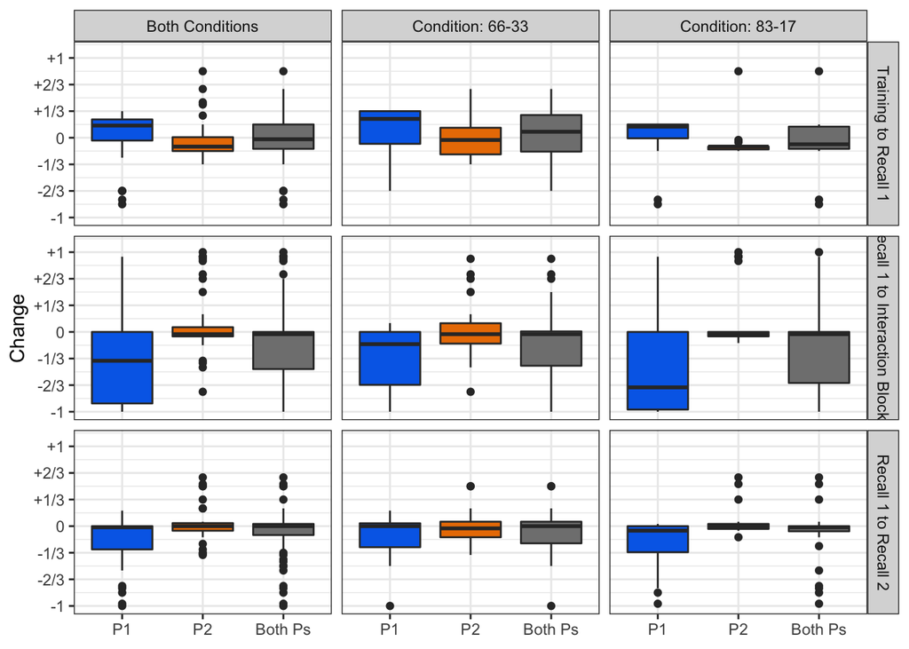

```r
ggplot(data=subset(exp1.change.data.for.plotting.combined,BlockToBlock%in% c("Training to Recall 1","Recall 1 to Interaction Block 2","Recall 1 to Recall 2")), aes(x=Participant, y=Change, fill=Participant)) +
  theme_bw() +
  facet_grid(BlockToBlock~Condition) +
  geom_boxplot() +
  scale_fill_manual(values=c(my.colours[2],my.colours[1],my.colours[3])) +
  scale_y_continuous(limits = c(-1,1.1),breaks=seq(-1,1,1/3),labels=c("-1","-2/3","-1/3","0","+1/3","+2/3","+1")) +
  ylab("Change") +
  theme(axis.title.x = element_blank()) +
  theme(legend.position="none")
```

# Plot within-pair differences and do statistics over these

We can measure alignment using within-pair difference in marker usage - lower within-pair difference is indicative of higher alignment.

## Plots showing within-pair differences

```r
# The easiest way to do this is to build a wide-format table by subsetting based on P then merging

p1 <- dplyr::select(subset(exp1.data.by.block,Participant=="P1"),-Participant,-ParticipantID)
p2 <- dplyr::select(subset(exp1.data.by.block,Participant=="P2"),-Participant,-ParticipantID)
exp1.diffs <- merge(p1,p2,by=c('Condition','Pair','Block','BlockNewlines'))

#calculate absolute diffs
exp1.diffs$Difference <- abs(exp1.diffs$ProportionMarkedSingulars.x-exp1.diffs$ProportionMarkedSingulars.y)

#remove unnecessary columns, reorder Block again
exp1.diffs <- dplyr::select(exp1.diffs,-ProportionMarkedSingulars.x,-ProportionMarkedSingulars.y)
```

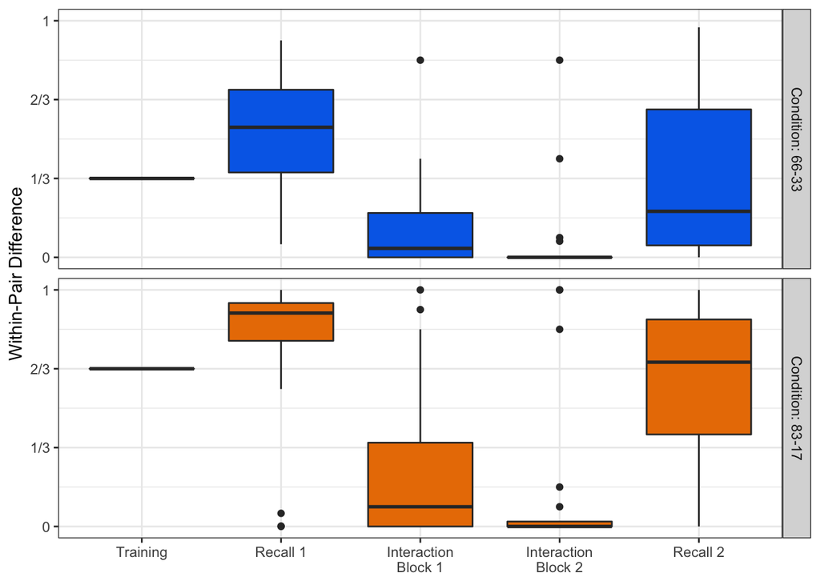

```r
ggplot(data=exp1.diffs, aes(x=BlockNewlines, y=Difference, fill=Condition,ymin=0,ymax=1)) +
  theme_bw() +
  geom_boxplot() +
  facet_grid(Condition~.) +
  scale_fill_manual(values=c(my.colours[2],my.colours[1],my.colours[3])) +
  scale_y_continuous(breaks=seq(0,1,1/3),labels=c("0","1/3","2/3","1")) +
  ylab("Within-Pair Difference") +
  theme(axis.title.x = element_blank()) +
  theme(legend.position="none")
```

## Plots and stats on change in within-pair differences

Also useful to show the change in within-pair differences over time.

```r
#The most convenient way to calculate differences from block to block is to restructure the data to wide format.
exp1.diffs.change.data <- tidyr::spread(data=dplyr::select(exp1.diffs,-BlockNewlines),Block,Difference)

exp1.diffs.change.data$ChangeTrainingRecall1 <- exp1.diffs.change.data$'Recall 1' - exp1.diffs.change.data$'Training'

exp1.diffs.change.data$ChangeRecall1Interaction2 <- exp1.diffs.change.data$'Interaction Block 2'-exp1.diffs.change.data$'Recall 1'

exp1.diffs.change.data$ChangeRecall1Recall2 <- exp1.diffs.change.data$'Recall 2'-exp1.diffs.change.data$'Recall 1'


#convert back to long format for plotting
exp1.diffs.change.data.for.plotting <- dplyr::select(exp1.diffs.change.data,-Training,-'Recall 1',-'Recall 2',-'Interaction Block 1',-'Interaction Block 2')

exp1.diffs.change.data.for.plotting <- tidyr::gather(exp1.diffs.change.data.for.plotting,
BlockToBlock,DifferenceChange,ChangeTrainingRecall1,ChangeRecall1Interaction2,ChangeRecall1Recall2)

#Make column names more user-friendly
exp1.diffs.change.data.for.plotting$BlockToBlock <- plyr::revalue(exp1.diffs.change.data.for.plotting$BlockToBlock,
                                                   c("ChangeTrainingRecall1"="Training to Recall 1",
                                                     "ChangeRecall1Interaction2"="Recall 1 to Interaction Block 2",
                                                     "ChangeRecall1Recall2"="Recall 1 to Recall 2"))

#Now duplicate data and add in "Both Conditions" version, with all the data from both conditions, not seperated by Participant
exp1.diffs.change.data.for.plotting.Cscombined <- exp1.diffs.change.data.for.plotting
exp1.diffs.change.data.for.plotting.Cscombined$Condition <- "Both\nConditions"
exp1.diffs.change.data.for.plotting.combined <- rbind(exp1.diffs.change.data.for.plotting,exp1.diffs.change.data.for.plotting.Cscombined)

#reorder levels
#exp1.diffs.change.data.for.plotting.combined$Condition <- relevel(exp1.diffs.change.data.for.plotting.combined$Condition,ref="Both\nConditions")
```

## Plots and stats for change in within-pair difference due to interaction (change from Recall 1 to Interaction 2)

### Plots of change in within-pair difference from Recall 1 to Interaction 2

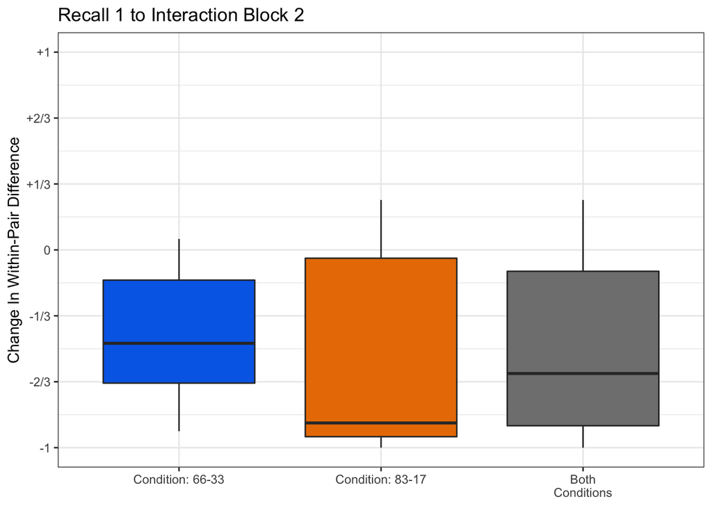

```r
ggplot(data=subset(exp1.diffs.change.data.for.plotting.combined,BlockToBlock=="Recall 1 to Interaction Block 2"), aes(x=Condition, y=DifferenceChange, fill=Condition)) +
  theme_bw() +
  geom_boxplot() +
  expand_limits(y=1) +
  scale_fill_manual(values=c(my.colours[2],my.colours[1],my.colours[3])) +
  scale_y_continuous(breaks=seq(-1,1,1/3),labels=c("-1","-2/3","-1/3","0","+1/3","+2/3","+1")) +
  ylab("Change In Within-Pair Difference") +
  theme(axis.title.x = element_blank()) +
  theme(legend.position="none") +
  ggtitle("Recall 1 to Interaction Block 2")
```

Q1: do the conditions differ in change from recall 1 to interaction 2? **Marginally**.

```r
wilcox.test(subset(exp1.diffs.change.data,Condition=="Condition: 66-33")$ChangeRecall1Interaction2,
            subset(exp1.diffs.change.data,Condition=="Condition: 83-17")$ChangeRecall1Interaction2)
```

```
##
##  Wilcoxon rank sum test with continuity correction
##
## data:  subset(exp1.diffs.change.data, Condition == "Condition: 66-33")$ChangeRecall1Interaction2 and subset(exp1.diffs.change.data, Condition == "Condition: 83-17")$ChangeRecall1Interaction2
## W = 265.5, p-value = 0.07852
## alternative hypothesis: true location shift is not equal to 0
```

Q2a: does the change from recall 1 to interaction 2 differ from 0? **Yes**.

```r
wilcox.test(exp1.diffs.change.data$ChangeRecall1Interaction2)
```

```
##
##  Wilcoxon signed rank test with continuity correction
##
## data:  exp1.diffs.change.data$ChangeRecall1Interaction2
## V = 26.5, p-value = 4.051e-07
## alternative hypothesis: true location is not equal to 0
```

Q2b: do the same seperately, by condition.

66-33 show the effect.

83-17 show the effect.

```r
wilcox.test(subset(exp1.diffs.change.data,Condition=="Condition: 66-33")$ChangeRecall1Interaction2)
```

```
##
##  Wilcoxon signed rank test with continuity correction
##
## data:  subset(exp1.diffs.change.data, Condition == "Condition: 66-33")$ChangeRecall1Interaction2
## V = 1.5, p-value = 0.0001203
## alternative hypothesis: true location is not equal to 0
```

```r
wilcox.test(subset(exp1.diffs.change.data,Condition=="Condition: 83-17")$ChangeRecall1Interaction2)
```

```
##
##  Wilcoxon signed rank test with continuity correction
##
## data:  subset(exp1.diffs.change.data, Condition == "Condition: 83-17")$ChangeRecall1Interaction2
## V = 11, p-value = 0.0007674
## alternative hypothesis: true location is not equal to 0
```

## Plots and stats for lasting effect of interaction on within-pair distance (change from recall 1 to recall 2)

### Plot of change in within-pair difference for recall 1 to recall 2.

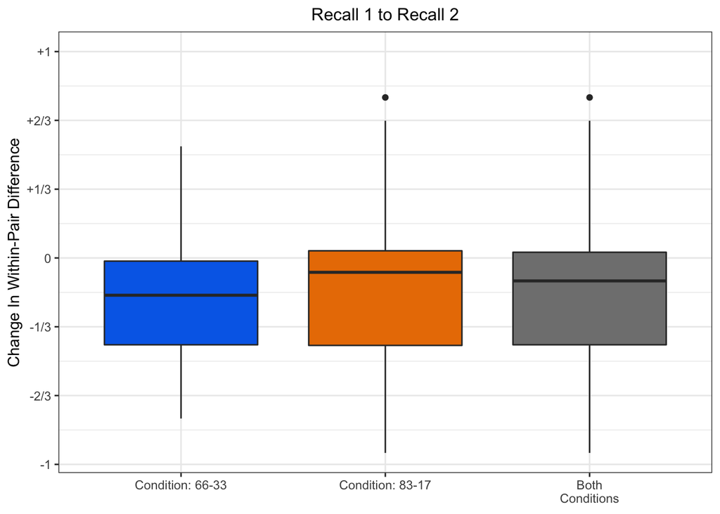

```r
ggplot(data=subset(exp1.diffs.change.data.for.plotting.combined,BlockToBlock=="Recall 1 to Recall 2"), aes(x=Condition, y=DifferenceChange, fill=Condition)) +
  theme_bw() +
  geom_boxplot() +
  expand_limits(y=1) +
  scale_fill_manual(values=c(my.colours[2],my.colours[1],my.colours[3])) +
  scale_y_continuous(breaks=seq(-1,1,1/3),labels=c("-1","-2/3","-1/3","0","+1/3","+2/3","+1")) +
  ylab("Change In Within-Pair Difference") +
  theme(axis.title.x = element_blank()) +
  #theme(strip.text.y = element_blank()) +
  theme(legend.position="none",plot.title = element_text(size=12,hjust=0.5)) +
  ggtitle("Recall 1 to Recall 2")
```

### Stats for change in within-pair difference from Recall 1 to Recall 2

This is another way of measuring lasting alignment.

Q1: do the conditions differ in change from recall 1 to recall 2? **No significant difference**.

```r
wilcox.test(subset(exp1.diffs.change.data,Condition=="Condition: 66-33")$ChangeRecall1Recall2,
            subset(exp1.diffs.change.data,Condition=="Condition: 83-17")$ChangeRecall1Recall2)
```

```
##
##  Wilcoxon rank sum test with continuity correction
##
## data:  subset(exp1.diffs.change.data, Condition == "Condition: 66-33")$ChangeRecall1Recall2 and subset(exp1.diffs.change.data, Condition == "Condition: 83-17")$ChangeRecall1Recall2
## W = 182.5, p-value = 0.6455
## alternative hypothesis: true location shift is not equal to 0
```

Q2: does the change from recall 1 to recall 2 differ from 0? **Yes**.

```r
wilcox.test(exp1.diffs.change.data$ChangeRecall1Recall2)
```

```
##
##  Wilcoxon signed rank test with continuity correction
##
## data:  exp1.diffs.change.data$ChangeRecall1Recall2
## V = 197, p-value = 0.007208
## alternative hypothesis: true location is not equal to 0
```

Q3: As per reviewer request, check this per condition. **Effect is significant for 66-33, n.s. for 83-17.**

```r
wilcox.test(subset(exp1.diffs.change.data,Condition=="Condition: 66-33")$ChangeRecall1Recall2)
```

```
##
##  Wilcoxon signed rank test with continuity correction
##
## data:  subset(exp1.diffs.change.data, Condition == "Condition: 66-33")$ChangeRecall1Recall2
## V = 43.5, p-value = 0.02266
## alternative hypothesis: true location is not equal to 0
```

```r
wilcox.test(subset(exp1.diffs.change.data,Condition=="Condition: 83-17")$ChangeRecall1Recall2)
```

```
##
##  Wilcoxon signed rank test with continuity correction
##
## data:  subset(exp1.diffs.change.data, Condition == "Condition: 83-17")$ChangeRecall1Recall2
## V = 58, p-value = 0.1418
## alternative hypothesis: true location is not equal to 0
```

## Combined plot showing change in within-pair difference

The most consistent way to show the change in within-pair difference from recall 1 to interaction 2 *and* recall 1 to recall 2 is a combined plot, using facet labels to identify the block.

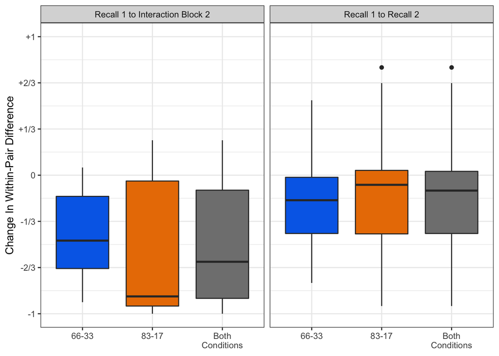

```r
#For this plot I need to use the shortened condition names to avoid problems with font size or the x-axis.
exp1.diffs.change.data.for.plotting.combined$ShortCondition <- plyr::revalue(exp1.diffs.change.data.for.plotting.combined$Condition,
                                                                       c("Condition: 66-33"="66-33",
                                                                         "Condition: 83-17"="83-17"))
ggplot(data=subset(exp1.diffs.change.data.for.plotting.combined,BlockToBlock %in% c("Recall 1 to Interaction Block 2","Recall 1 to Recall 2")), aes(x=ShortCondition, y=DifferenceChange, fill=ShortCondition)) +
  theme_bw() +
  facet_grid(.~BlockToBlock) +
  geom_boxplot() +
  expand_limits(y=1) +
  scale_fill_manual(values=c(my.colours[2],my.colours[1],my.colours[3])) +
  scale_y_continuous(breaks=seq(-1,1,1/3),labels=c("-1","-2/3","-1/3","0","+1/3","+2/3","+1")) +
  ylab("Change In Within-Pair Difference") +
  theme(axis.title.x = element_blank()) +
  #theme(strip.text.y = element_blank()) +
  theme(legend.position="none",plot.title = element_text(size=12,hjust=0.5))
```

# Additional analysis requested by a reviewer

One reviewer wanted to know if the reductions in within-pair difference we see here reflect alignment, or just the fact that everyone heads for zero marking and aligns coincidentally. We can test this in our data by seeing whether the observed changes in within-pair difference are greater than those we obtain if we randomly re-paired participants and re-calculated within-pair difference for these pseudo-pairs.

To do this we will calculate the mean within-pair difference at Interaction 2 for the veridical pairs, then calculate 1000 pseudo-pairings and evaluate how often these exhibit equal or lower mean within-pair difference. The random pseudo-pairings have to reflect the conditions and P1-P2 distinctions so as to avoid e.g. pairing a 66% participant with an 83% participant.

```r
veridical.mean.wpd <- mean(subset(exp1.diffs,Block=="Interaction Block 2")$Difference)

#make a copy of the data to work with - we only need interaction block 2 data
exp1.data.by.block.pseudo <- dplyr::select(subset(exp1.data.by.block,Block=="Interaction Block 2"),-Block,-BlockNewlines)

#helper function to re-assign participants to pseudo-pairs - slightly laoborious
#in order to avoid mixing across conditions etc
reassign.pairs <- function(in.data) {
  #subset data by block and participant
  p1.6633 <- dplyr::select(subset(in.data,Participant=="P1" & Condition=="Condition: 66-33"),-Participant,-ParticipantID)
  p2.6633 <- dplyr::select(subset(in.data,Participant=="P2" & Condition=="Condition: 66-33"),-Participant,-ParticipantID)
  p1.8317 <- dplyr::select(subset(in.data,Participant=="P1" & Condition=="Condition: 83-17"),-Participant,-ParticipantID)
  p2.8317 <- dplyr::select(subset(in.data,Participant=="P2" & Condition=="Condition: 83-17"),-Participant,-ParticipantID)

  #randomise pair assignments
  p1.6633$Pair <- sample(p1.6633$Pair)
  p2.6633$Pair <- sample(p2.6633$Pair)
  p1.8317$Pair <- sample(p1.8317$Pair)
  p2.8317$Pair <- sample(p2.8317$Pair)

  diffs.pseudo.6633 <- merge(p1.6633,p2.6633,by=c('Condition','Pair'))
  diffs.pseudo.8317 <- merge(p1.8317,p2.8317,by=c('Condition','Pair'))
  diffs.pseudo <- rbind(diffs.pseudo.6633,diffs.pseudo.8317)

  #calculate absolute diffs
  diffs.pseudo$Difference <-
    abs(diffs.pseudo$ProportionMarkedSingulars.x-diffs.pseudo$ProportionMarkedSingulars.y)

  #remove unnecessary columns, reorder Block again
  diffs.pseudo <- dplyr::select(diffs.pseudo,-ProportionMarkedSingulars.x,-ProportionMarkedSingulars.y)

  #calculate and return mean
  mean(diffs.pseudo$Difference)
}

sampled.diffs <- replicate(1000,reassign.pairs(exp1.data.by.block.pseudo))

#report the veridfical within-pair difference
veridical.mean.wpd
```

```
## [1] 0.1121212
```

```r
#report the mean of the sampled diffs
mean(sampled.diffs)
```

```
## [1] 0.4572348
```

```r
#this is the number of cases where we see the same or smaller within-pair difference
sum(sampled.diffs <= veridical.mean.wpd)
```

```
## [1] 0
```

```r
#this is the proportion of cases where we see the same or smaller within-pair difference
sum(sampled.diffs <= veridical.mean.wpd)/length(sampled.diffs)
```

```
## [1] 0
```

# Difference in change within each pair

This might be a way of testing for interactions - i.e. P1 and P2 change from time 1 to time 2, they might differ in the amount they change, is that difference the same across conditions (if not, that would suggest an interaction effect).

The way we calculate this is very similar to the way we calculate within-pair differences, but based on the change scores per particpant, not the raw frequencies.

```r
#The most convenient way to calculate differences from block to block is to restructure the data to wide format.
exp1.change.in.diffs.data <- tidyr::spread(data=dplyr::select(exp1.change.data.for.plotting,-ParticipantID),Participant,Change)

exp1.change.in.diffs.data$DifferenceInChange <- exp1.change.in.diffs.data$P1 - exp1.change.in.diffs.data$P2
```

### Plots of difference in change from Training to Recall 1

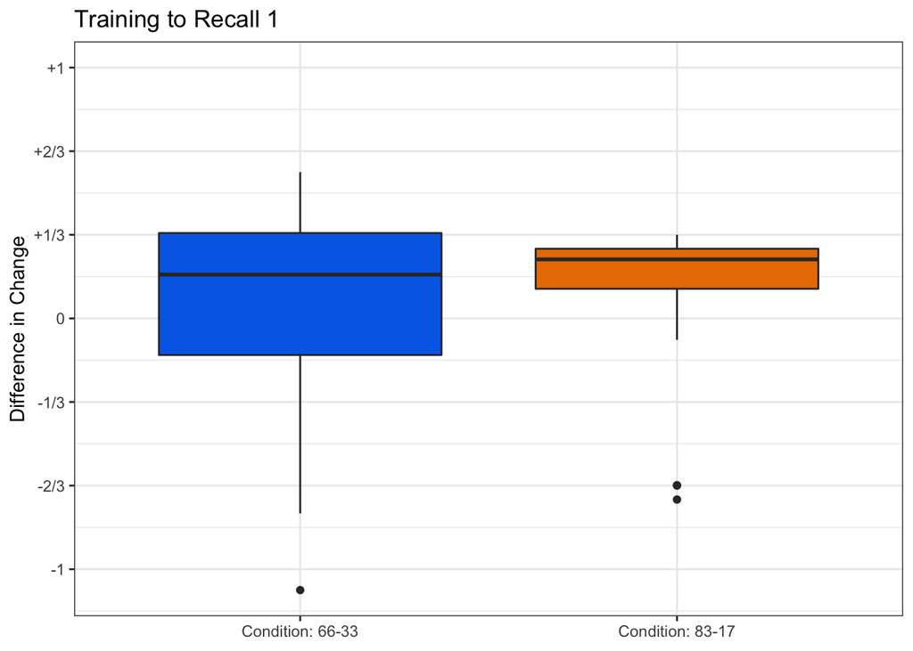

```r
ggplot(data=subset(exp1.change.in.diffs.data,BlockToBlock=="Training to Recall 1"), aes(x=Condition, y=DifferenceInChange, fill=Condition)) +
  theme_bw() +
  geom_boxplot() +
  expand_limits(y=1) +
  scale_fill_manual(values=c(my.colours[2],my.colours[1],my.colours[3])) +
  scale_y_continuous(breaks=seq(-1,1,1/3),labels=c("-1","-2/3","-1/3","0","+1/3","+2/3","+1")) +
  ylab("Difference in Change") +
  theme(axis.title.x = element_blank()) +
  theme(legend.position="none") +
  ggtitle("Training to Recall 1")
```

```r
wilcox.test(subset(exp1.change.in.diffs.data,Condition=="Condition: 66-33" & BlockToBlock=="Training to Recall 1")$DifferenceInChange,
            subset(exp1.change.in.diffs.data,Condition=="Condition: 83-17" & BlockToBlock=="Training to Recall 1")$DifferenceInChange)
```

```
##
##  Wilcoxon rank sum test with continuity correction
##
## data:  subset(exp1.change.in.diffs.data, Condition == "Condition: 66-33" &  and subset(exp1.change.in.diffs.data, Condition == "Condition: 83-17" &     BlockToBlock == "Training to Recall 1")$DifferenceInChange and     BlockToBlock == "Training to Recall 1")$DifferenceInChange
## W = 207, p-value = 0.8604
## alternative hypothesis: true location shift is not equal to 0
```

### Plots of difference in change from Recall 1 to Interaction 2

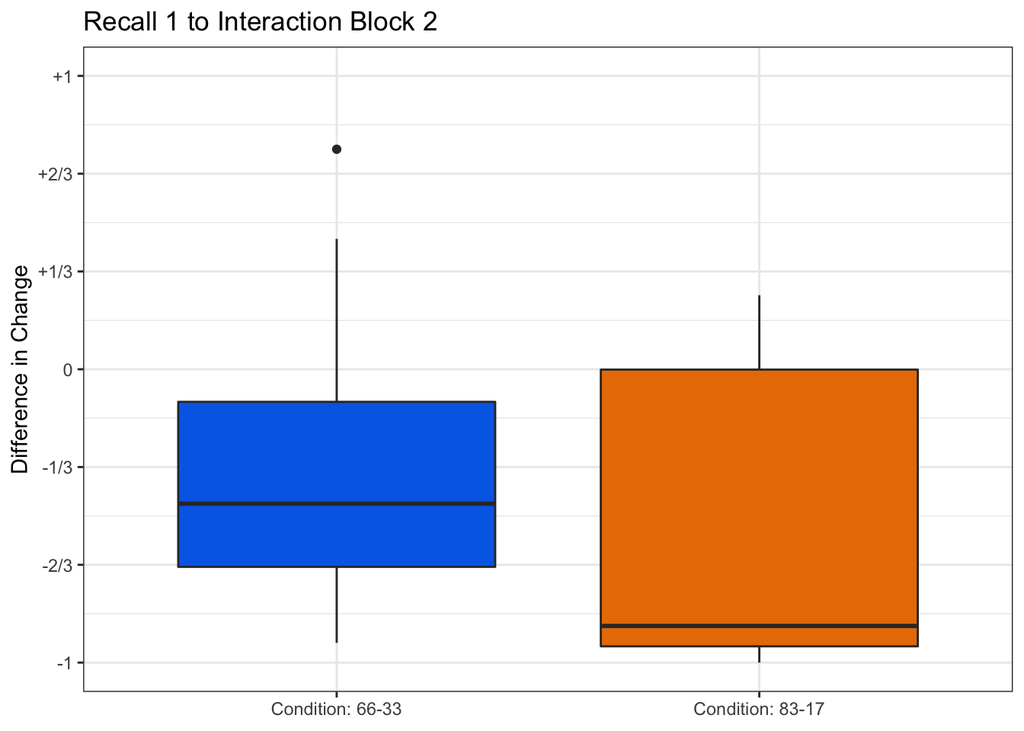

```r
ggplot(data=subset(exp1.change.in.diffs.data,BlockToBlock=="Recall 1 to Interaction Block 2"), aes(x=Condition, y=DifferenceInChange, fill=Condition)) +
  theme_bw() +
  geom_boxplot() +
  expand_limits(y=1) +
  scale_fill_manual(values=c(my.colours[2],my.colours[1],my.colours[3])) +
  scale_y_continuous(breaks=seq(-1,1,1/3),labels=c("-1","-2/3","-1/3","0","+1/3","+2/3","+1")) +
  ylab("Difference in Change") +
  theme(axis.title.x = element_blank()) +
  theme(legend.position="none") +
  ggtitle("Recall 1 to Interaction Block 2")
```

```r
wilcox.test(subset(exp1.change.in.diffs.data,Condition=="Condition: 66-33" & BlockToBlock=="Recall 1 to Interaction Block 2")$DifferenceInChange,
            subset(exp1.change.in.diffs.data,Condition=="Condition: 83-17" & BlockToBlock=="Recall 1 to Interaction Block 2")$DifferenceInChange)
```

[output not shown]

### Plots of difference in change from Recall 1 to Recall 2

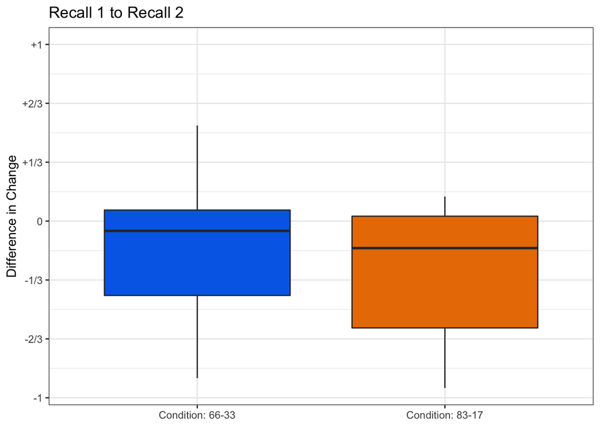

```r
ggplot(data=subset(exp1.change.in.diffs.data,BlockToBlock=="Recall 1 to Recall 2"), aes(x=Condition, y=DifferenceInChange, fill=Condition)) +
  theme_bw() +
  geom_boxplot() +
  expand_limits(y=1) +
  scale_fill_manual(values=c(my.colours[2],my.colours[1],my.colours[3])) +
  scale_y_continuous(breaks=seq(-1,1,1/3),labels=c("-1","-2/3","-1/3","0","+1/3","+2/3","+1")) +
  ylab("Difference in Change") +
  theme(axis.title.x = element_blank()) +
  theme(legend.position="none") +
  ggtitle("Recall 1 to Recall 2")
```

```r
wilcox.test(subset(exp1.change.in.diffs.data,Condition=="Condition: 66-33" & BlockToBlock=="Recall 1 to Recall 2")$DifferenceInChange,
            subset(exp1.change.in.diffs.data,Condition=="Condition: 83-17" & BlockToBlock=="Recall 1 to Recall 2")$DifferenceInChange)
```

```
##
##  Wilcoxon rank sum test with continuity correction
##
## data:  subset(exp1.change.in.diffs.data, Condition == "Condition: 66-33" &  and subset(exp1.change.in.diffs.data, Condition == "Condition: 83-17" &     BlockToBlock == "Recall 1 to Recall 2")$DifferenceInChange and     BlockToBlock == "Recall 1 to Recall 2")$DifferenceInChange
## W = 247, p-value = 0.2082
## alternative hypothesis: true location shift is not equal to 0
```